# Исследование объявлений о продаже квартир

#### Изменение типа данных

```python
df['is_apartment'] = df['is_apartment'].astype('bool')
df['studio'] = df['studio'].astype('bool')
df['open_plan'] = df['open_plan'].astype('bool')
df['balcony'] = df['balcony'].astype('int64')
df['parks_around3000'] = df['parks_around3000'].astype('int64')
df['ponds_around3000'] = df['ponds_around3000'].astype('int64')
```

```python
# посмотрим, что получилось
df.info()
```

```
<class 'pandas.core.frame.DataFrame'>
Int64Index: 21752 entries, 0 to 23698
Data columns (total 22 columns):
 #   Column                Non-Null Count  Dtype
---  ------                --------------  -----
 0   total_images          21752 non-null  int64
 1   last_price            21752 non-null  float64
 2   total_area            21752 non-null  float64
 3   first_day_exposition  21752 non-null  datetime64[ns]
 4   rooms                 21752 non-null  int64
 5   ceiling_height        13693 non-null  float64
 6   floors_total          21700 non-null  float64
 7   living_area           21752 non-null  float64
 8   floor                 21752 non-null  int64
 9   is_apartment          21752 non-null  bool
 10  studio                21752 non-null  bool
 11  open_plan             21752 non-null  bool
 12  kitchen_area          20943 non-null  float64
 13  balcony               21752 non-null  int64
 14  locality_name         21752 non-null  object
 15  airports_nearest      16842 non-null  float64
 16  cityCenters_nearest   16863 non-null  float64
 17  parks_around3000      21752 non-null  int64
 18  parks_nearest         7488 non-null   float64
 19  ponds_around3000      21752 non-null  int64
 20  ponds_nearest         8391 non-null   float64
 21  days_exposition       18770 non-null  float64
dtypes: bool(3), datetime64[ns](1), float64(11), int64(6), object(1)
memory usage: 3.4+ MB
```

is_apartment, open_plan, studio имеют значения 'true' , 'false' поэтому должны быть типа 'bool' balcony, parks_around3000, ponds_around3000 - целочисленные по определению.

#### Определение выбросов

```python
import numpy as np
```

```python
# В данном случае попробуем скорее искать ошибки в данных, нежели, чем выбросы. Для этого придется применять разные подходы:
# total_images - может быть сколько угодно фотографий объекта. Выбросы не считаем
```

```python
# last_price - цена может быть сколь угодно большой, но не может быть, предположим, меньше 400 тыс руб. Удалим такие строки
s = len(df)
df = df.query('last_price>=400000')
print('Удалено:', s-len(df), 'строк')
```

```
Удалено: 1 строк
```

```python
#total_area, first_day_exposition могут быть любыми
```

```python
#rooms не может быть равно 0, должна быть хотя бы одна
s = len(df)
df = df.query('rooms!=0')
print('Удалено:', s-len(df), 'строк')
```

```
Удалено: 183 строк
```

```python
#высота потолка не может быть меньше 2 м, будем считать это ошибкой ввода, удалим их
s = len(df)
df = df.query('ceiling_height>=2|ceiling_height.isna()')
print('Удалено:', s-len(df), 'строк')
```

```
Удалено: 3 строк
```

```python
#высота потолка от 20 до 35 м - опечатка в точке. Скорее всего, надо поделить на 10
print(df.query('ceiling_height>=20&ceiling_height<35')['ceiling_height'])
condition = (df['ceiling_height']>=20)&(df['ceiling_height']<=35)
df['ceiling_height'] = df['ceiling_height'].where(~condition, other=df['ceiling_height']/10)
```

```
355      25.0
3148     32.0
4643     25.0
5076     24.0
5246     27.0
5669     26.0
5807     27.0
6246     25.0
9379     25.0
10773    27.0
11285    25.0
14382    25.0
17496    20.0
17857    27.0
18545    25.0
20478    27.0
20507    22.6
21377    27.5
21824    27.0
22336    32.0
22938    27.0
Name: ceiling_height, dtype: float64
```

```python
#Проверим, как сработало
print(df.query('ceiling_height>=20&ceiling_height<30')['ceiling_height'])
# также проверим, не поделилил ли правильный высоты (не получилось ли что-то меньше 1)
print(df.query('ceiling_height<1')['ceiling_height'])
```

```
Series([], Name: ceiling_height, dtype: float64)
Series([], Name: ceiling_height, dtype: float64)
```

```python
#Посмтрим, есть ли что-то больше 5м
print(df.query('ceiling_height>5')['ceiling_height'])
```

```
464        5.2
1026       5.3
3474       8.0
5863       8.3
7578       5.5
15061     14.0
15743      8.0
17442      8.0
20264      6.0
22309     10.3
22869    100.0
Name: ceiling_height, dtype: float64
```

```python
len(df.query('ceiling_height<6|ceiling_height.isna()')['ceiling_height'])
```

```
21557
```

```python
#вероятно, то, что > 6 м - ошибки  в данных. Удалим
s = len(df)
df = df.query('ceiling_height<6|ceiling_height.isna()')
print('Удалено:', s-len(df), 'строк')
```

```
Удалено: 8 строк
```

```python
# посмотрим, что получилось в итоге
display(df.isnull().sum().sort_values(ascending = False))
print('Размер базы в итоге', len(df))
```

```
parks_nearest           14101
ponds_nearest           13233
ceiling_height           7953
airports_nearest         4835
cityCenters_nearest      4814
days_exposition          2970
kitchen_area              624
floors_total               52
ponds_around3000            0
parks_around3000            0
locality_name               0
balcony                     0
total_images                0
last_price                  0
studio                      0
is_apartment                0
floor                       0
living_area                 0
rooms                       0
first_day_exposition        0
total_area                  0
open_plan                   0
dtype: int64
```

```
Размер базы в итоге 21557
```

По итогу видно, что мы избавились от значимых нулевых строк, без потери большого количества данных

### Посчитайте и добавьте в таблицу новые столбцы

```python
# добавим в таблицу цену 1 кв.м.
df['one_meter_price'] = df['last_price'] / df['total_area'].round(decimals=2)
```

```python
# добавим в таблицу день недели публикации объявления (0 — понедельник, 1 — вторник и так далее)
#                   месяц публикации
#                   год публикации
df['first_day_exposition'] = pd.to_datetime(df['first_day_exposition'], format="%Y-%m-%dT%H:%M:%S")
df['day_of_week_exposition'] = df['first_day_exposition'].dt.dayofweek
df['month_exposition'] = df['first_day_exposition'].dt.month
df['year_exposition'] = df['first_day_exposition'].dt.year
```

```python
# добавим в таблицу тип этажа квартиры (значения — «первый», «последний», «другой»)
def floor_name(row):
    if row['floor'] == 1:
        return 'первый'
    elif row['floor'] == row['floors_total']:
        return 'последний'
    else:
        return 'другой'
df['floor_name'] = df.apply(floor_name, axis=1)
```

```python
df['cityCenters_nearest_km'] = (df['cityCenters_nearest'] / 1000).round(decimals=0)
```

### Проведите исследовательский анализ данных

#### параметры объектов

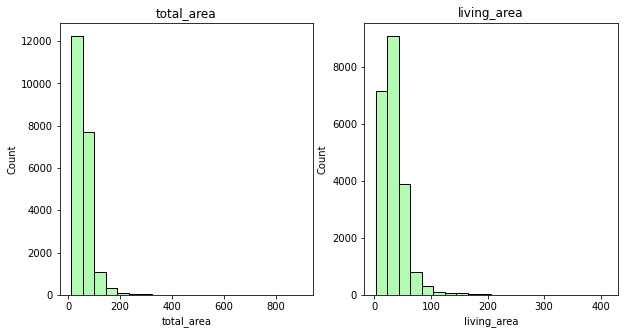

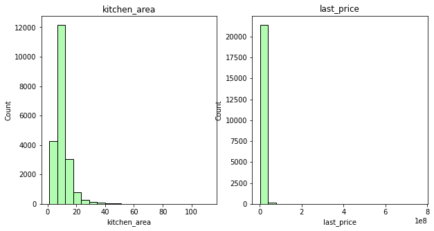

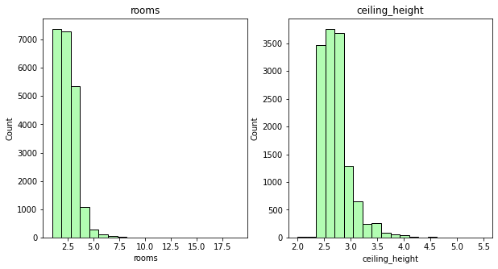

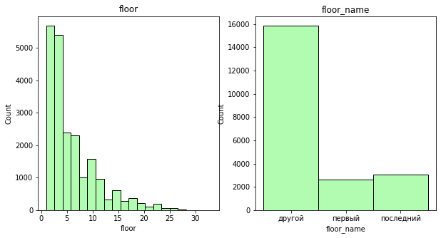

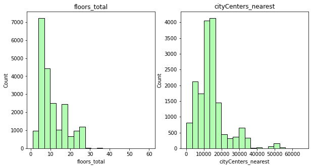

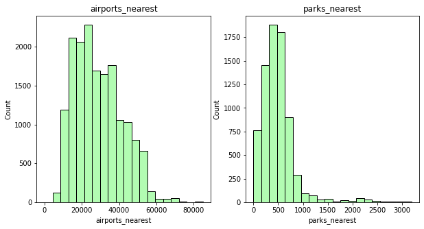

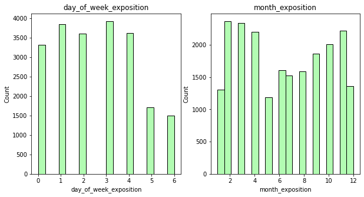

```python
# создадим список из столбцов, по которым будем проводить анализ
import matplotlib.pyplot as plt
import seaborn as sns

s = ['total_area', 'living_area', 'kitchen_area', 'last_price', 'rooms', 'ceiling_height', 'floor','floor_name','floors_total',
    'cityCenters_nearest','airports_nearest','parks_nearest', 'day_of_week_exposition','month_exposition' ]

i=1
for elem in s:
    if i%2 != 0:
        fig = plt.figure(figsize=(10,5))
        ax = fig.add_subplot(121)
        sns.histplot(df[elem], kde=False, bins=20, color='palegreen')

        plt.title(elem)
    else:
        ax = fig.add_subplot(122)
        sns.histplot(df[elem], kde=False, bins=20, color='palegreen')

        plt.title(elem)
    i+=1
plt.show()
```

По представленным диаграммам можно сделать следующие выводы:

1. По площади преобладают небольшие квартиры - около 50 метров с жилой площадью около 25 метров. Очень мало квартир больше 100 м.кв.
2. Значительный отрыв у квартир с небольшой кужхней (до 10 м.кв.). При этом, следует учитыавать, что много где размер кухонь не указан, из чего можно сделать вывод о совмещенности кухни с гостиной
3. Значительная часть квартир продается в малоэтажных домах (до 5 этажей) не на первом и не на последнем этажах
4. Большинство квартир продается на расстоянии от 10 до 20 км от центра. Что соответствует крупным городам. Но непонятно, что считать расстоянием до центра в небольших населенных пунктах. Можно предположить, что по небольшим населенным пунктам это значение не указано.
5. Большая часть квартир в выборке представлена до 40 км до аэропорта. Хотя, много квартир, у которых такое расстояние не указано.
6. Среднее расстояние до парка составляет до 1 км.

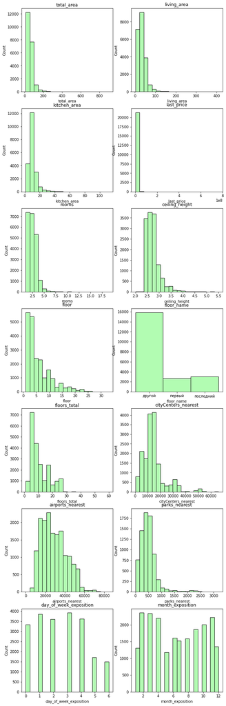

```python
fig, axes = plt.subplots(len(s) // 2 + 1,2, figsize=(10,40))

for elem,ax in zip(s, axes.flat):

    sns.histplot(df[elem], kde=False, bins=20, color='palegreen', ax=ax)
    ax.set_title(elem)

for ax in axes.flat[len(s)::]:
    fig.delaxes(ax)
plt.show()
```

#### Исследование сроков продаж

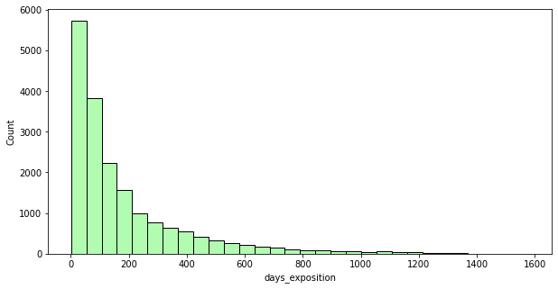

```python
fig = plt.figure(figsize=(10,5))
#ax = fig.add_subplot(121)
sns.histplot(df['days_exposition'], kde=False, bins=30, color='palegreen')
```

```python
print('Среднее значение сроков продажи', df['days_exposition'].mean().round(0))
print('Медианное значение сроков продажи', df['days_exposition'].median().round(0))
```

```
Среднее значение сроков продажи 185.0
Медианное значение сроков продажи 102.0
```

```python
#уберем выбросы и посмотрим сроки продажи без них
def delete_outliers(table, col):
    q1 = table[col].quantile(0.25)
    q3 = table[col].quantile(0.75)
    iqr = q3 - q1
    filt = (table[col] >= (q1 - 1.5*iqr)) & (table[col] <= (q3 + 1.5*iqr))
    return table.loc[filt]
```

```python
print('Среднее значение сроков продажи', delete_outliers(df, 'days_exposition')['days_exposition'].mean().round(0))
print('Медианное значение сроков продажи', delete_outliers(df, 'days_exposition')['days_exposition'].median().round(0))
```

```
Среднее значение сроков продажи 134.0
Медианное значение сроков продажи 90.0
```

К быстрым продажам я бы отнес продажи менее 90 дней. А к медленным - сильно больше 140 дней

#### Факторы, влияющие на цену

```python
#Построим таблицу зависимостей цены квартиры от
# общей площади;
# жилой площади;
# площади кухни;
# количества комнат;
# этажа, на котором расположена квартира (первый, последний, другой);
# даты размещения (день недели, месяц, год)
v = ['last_price','total_area', 'living_area', 'kitchen_area', 'rooms', 'floor_name', 'day_of_week_exposition', 'month_exposition', 'year_exposition']

stat_price = df[v]
```

```python
stat_price.corr()
```

|  | last_price | total_area | living_area | kitchen_area | rooms | day_of_week_exposition | month_exposition | year_exposition |
| --- | --- | --- | --- | --- | --- | --- | --- | --- |
| last_price | 1.000000 | 0.641825 | 0.565407 | 0.519545 | 0.362030 | 0.000621 | 0.001977 | -0.038801 |
| total_area | 0.641825 | 1.000000 | 0.939497 | 0.609252 | 0.773483 | -0.005644 | 0.005002 | -0.080789 |
| living_area | 0.565407 | 0.939497 | 1.000000 | 0.429128 | 0.850163 | -0.004828 | -0.001461 | -0.071620 |
| kitchen_area | 0.519545 | 0.609252 | 0.429128 | 1.000000 | 0.270385 | -0.008677 | 0.003364 | -0.059905 |
| rooms | 0.362030 | 0.773483 | 0.850163 | 0.270385 | 1.000000 | -0.002331 | -0.003011 | -0.052044 |
| day_of_week_exposition | 0.000621 | -0.005644 | -0.004828 | -0.008677 | -0.002331 | 1.000000 | 0.009401 | -0.007920 |
| month_exposition | 0.001977 | 0.005002 | -0.001461 | 0.003364 | -0.003011 | 0.009401 | 1.000000 | -0.256398 |
| year_exposition | -0.038801 | -0.080789 | -0.071620 | -0.059905 | -0.052044 | -0.007920 | -0.256398 | 1.000000 |

```python
# Код ревьюера

(df[v[1:]].corrwith(df['last_price']))
```

```
total_area                0.641825
living_area               0.565407
kitchen_area              0.519545
rooms                     0.362030
day_of_week_exposition    0.000621
month_exposition          0.001977
year_exposition          -0.038801
dtype: float64
```

```python
# По результатам видно, что зависимость цены от эих показателей, безусловно, есть, но она не слишком серьезная. Наибольшая корреляция,
# как и ожидалось, между ценой и общей площадью.
# попробуем посмотреть, усилится ли зависимость, если мы удалим выбросы из показателя "total_area"
s = delete_outliers(stat_price,'total_area')
s.corr()
#увеличение незначительное
```

|  | last_price | total_area | living_area | kitchen_area | rooms | day_of_week_exposition | month_exposition | year_exposition |
| --- | --- | --- | --- | --- | --- | --- | --- | --- |
| last_price | 1.000000 | 0.687153 | 0.550718 | 0.522442 | 0.392791 | -0.015388 | -0.000723 | -0.011127 |
| total_area | 0.687153 | 1.000000 | 0.905812 | 0.478425 | 0.789911 | -0.011096 | 0.005714 | -0.060991 |
| living_area | 0.550718 | 0.905812 | 1.000000 | 0.176906 | 0.887464 | -0.006130 | -0.000186 | -0.049069 |
| kitchen_area | 0.522442 | 0.478425 | 0.176906 | 1.000000 | 0.072929 | -0.015179 | 0.010772 | -0.038031 |
| rooms | 0.392791 | 0.789911 | 0.887464 | 0.072929 | 1.000000 | 0.000994 | 0.000610 | -0.032767 |
| day_of_week_exposition | -0.015388 | -0.011096 | -0.006130 | -0.015179 | 0.000994 | 1.000000 | 0.009691 | -0.008639 |
| month_exposition | -0.000723 | 0.005714 | -0.000186 | 0.010772 | 0.000610 | 0.009691 | 1.000000 | -0.254417 |
| year_exposition | -0.011127 | -0.060991 | -0.049069 | -0.038031 | -0.032767 | -0.008639 | -0.254417 | 1.000000 |

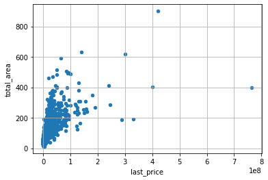

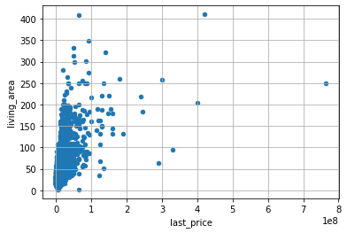

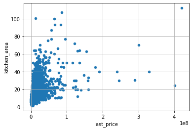

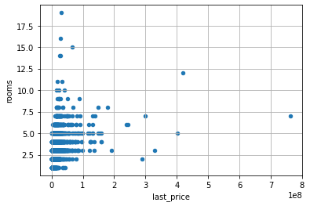

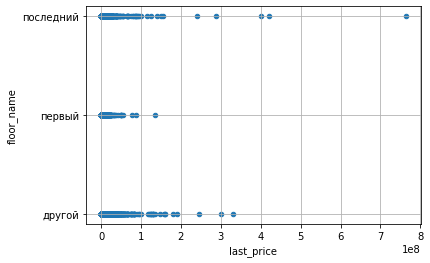

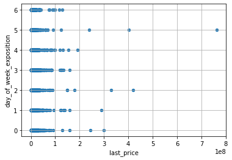

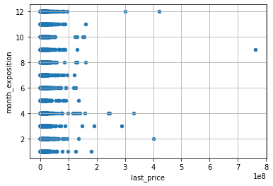

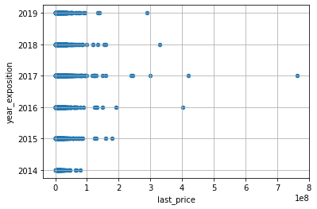

```python
v = ['total_area', 'living_area', 'kitchen_area', 'rooms', 'floor_name', 'day_of_week_exposition', 'month_exposition', 'year_exposition']

for i in range(len(v)):
    stat_price.plot(x='last_price', y=v[i], grid = True, kind = 'scatter')
```

Из представленных графиков видно, что зависимость цены объекта от площадей (общей, жилой и кухни, а также количества комнат) присутствует, но данная зависимость хоть и основополагающая, но явно присутствуют другие факторы, влияющие на цену. По проочим факторам (дни недели, и проч.) зависимости не обнаружено

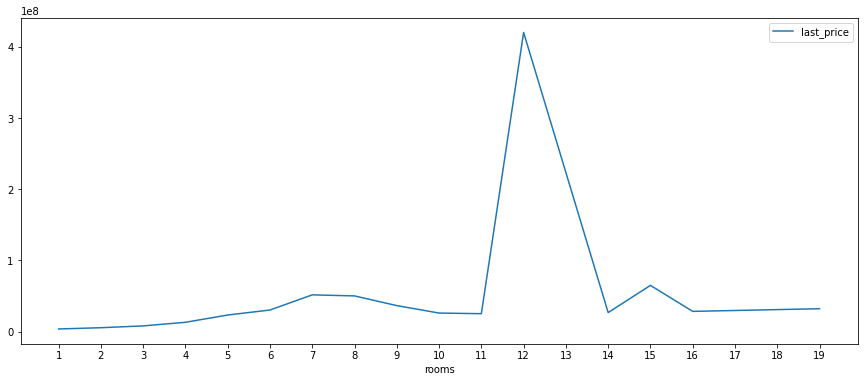

```python
# Код ревьюера
import matplotlib.ticker as ticker

ax = stat_price.groupby('rooms').agg({'last_price' : 'mean'}).plot(figsize=(15,6))
ax.xaxis.set_major_locator(ticker.MultipleLocator(1))
```

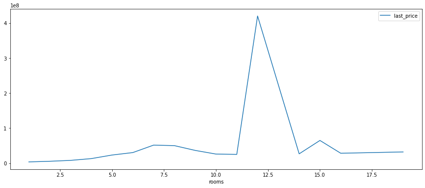

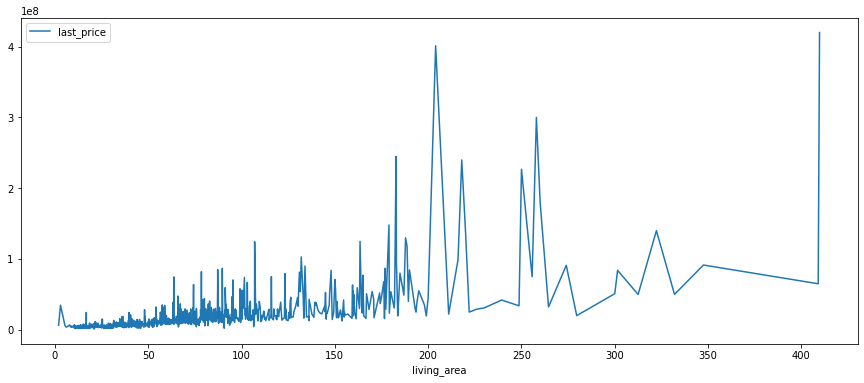

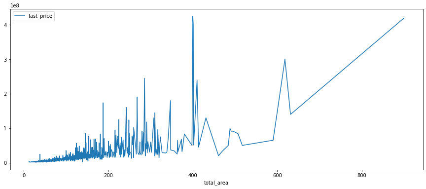

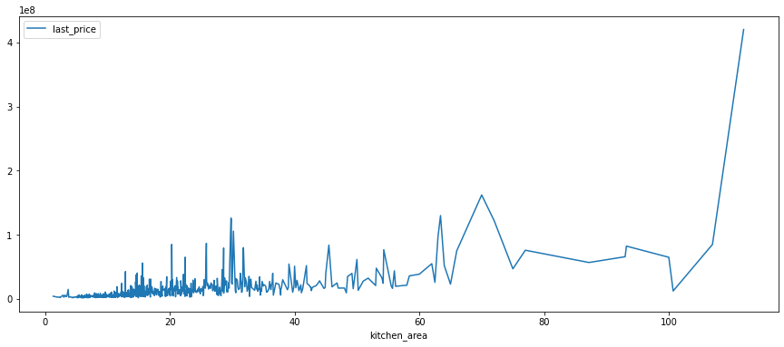

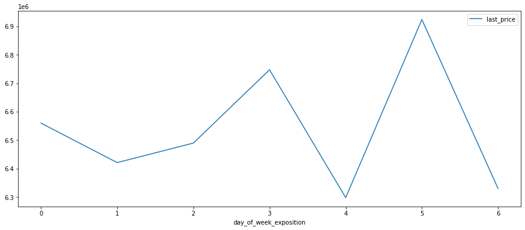

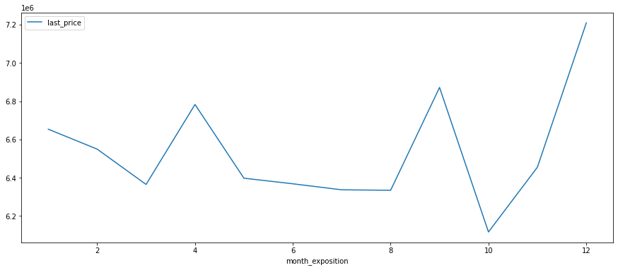

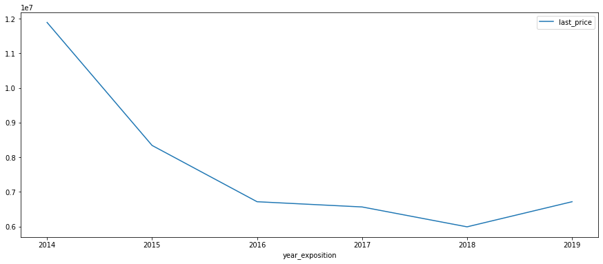

```python
for mean in ['rooms', 'living_area', 'total_area', 'kitchen_area', 'day_of_week_exposition', 'month_exposition', 'year_exposition']:
    ax = stat_price.groupby(mean).agg({'last_price' : 'mean'}).plot(figsize=(15,6))
```

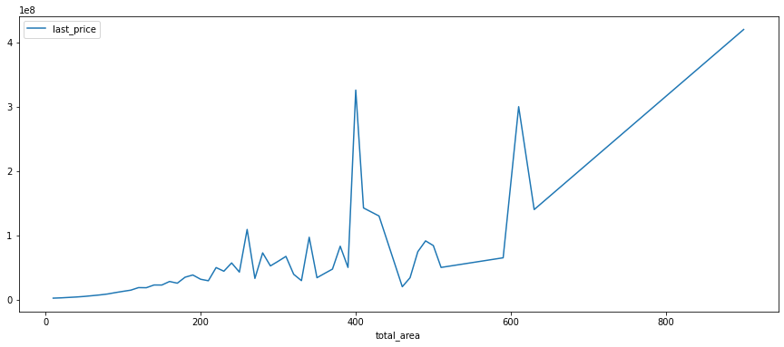

```python
# Код ревьюера

stat_price.groupby(stat_price['total_area'] // 10 * 10).agg({'last_price' : 'mean'}).plot(figsize=(15,6))
```

#### Средняя стоимость квадратного метра

```python
# Посчитаем среднюю цену одного квадратного метра в 10 населённых пунктах с наибольшим числом объявлений

stat_grouped = (df.pivot_table(index='locality_name', values='one_meter_price', aggfunc=['mean', 'count']))
stat_grouped.columns=['mean', 'count']
stat_grouped.sort_values(by='count', ascending = False).head(10)
```

| locality_name | mean | count |
| --- | --- | --- |
| Санкт-Петербург | 114083.849383 | 14469 |
| Мурино | 86082.737721 | 498 |
| Кудрово | 95541.709329 | 403 |
| Шушары | 78580.964710 | 401 |
| Всеволожск | 68873.630029 | 366 |
| Пушкин | 103428.483885 | 345 |
| Колпино | 75344.096345 | 328 |
| Парголово | 90570.011495 | 297 |
| Гатчина | 68627.363919 | 292 |
| Петергоф | 84480.969944 | 197 |

Вывод. Самая большая стоимость метра - в Санкт-Петербурге. Самая маленькая - в Гатчине. Что, в общем, логично

```python
# Код ревьюера

stat_grouped.sort_values(by='count', ascending = False).head(10).style.format('{:,.0f}')
```

| locality_name | mean | count |
| --- | --- | --- |
| Санкт-Петербург | 114,084 | 14,469 |
| Мурино | 86,083 | 498 |
| Кудрово | 95,542 | 403 |
| Шушары | 78,581 | 401 |
| Всеволожск | 68,874 | 366 |
| Пушкин | 103,428 | 345 |
| Колпино | 75,344 | 328 |
| Парголово | 90,570 | 297 |
| Гатчина | 68,627 | 292 |
| Петергоф | 84,481 | 197 |

#### Подсчет стоимости 1 км от центра по СПб

```python
# удалим NAN в столбце cityCenters_nearest_km, иначе ничего не сосчитаем
stat_grouped_1 = delete_outliers(df.loc[df['locality_name']=='Санкт-Петербург'][['last_price', 'cityCenters_nearest_km']], 'cityCenters_nearest_km')

#удалим нули 'cityCenters_nearest_km
stat_grouped_1 = stat_grouped_1.query('cityCenters_nearest_km!=0')

#Посмотрим, сколько строк осталось и сравним с тем,  сколько было (14469)
print('В ходе преобразований потеряли', 14469 - len(stat_grouped_1), 'строк')

stat_grouped_1['km_price'] = (stat_grouped_1['last_price']/stat_grouped_1['cityCenters_nearest_km']).round(2)

print('Средняя стоимость километра составляет',stat_grouped_1['km_price'].mean().round(2) )
```

```
В ходе преобразований потеряли 135 строк
Средняя стоимость километра составляет 1373362.06
```

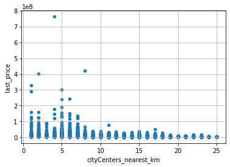

```python
#Построим график зависимости цены от расстояния до центра
stat_grouped_1.plot(y='last_price', x='cityCenters_nearest_km', grid = True, kind = 'scatter')
```

```python
stat_grouped_1.corr()
```

|  | last_price | cityCenters_nearest_km | km_price |
| --- | --- | --- | --- |
| last_price | 1.000000 | -0.252317 | 0.761468 |
| cityCenters_nearest_km | -0.252317 | 1.000000 | -0.283093 |
| km_price | 0.761468 | -0.283093 | 1.000000 |

Вывод. Слабая обратная корреляция между стоимости квартиры и удаленностью от центра имеется, однако, этот фактор имеет смысл рассматривать вместе с другими факторами

```python
# Посмотрим, какие варианты километражей по СПб есть вообще
print('Варианты расстояний от центра', df.query('locality_name=="Санкт-Петербург"')['cityCenters_nearest_km'].unique())

# Посчитаем сколько MA расстояний по СПб
print('Незаполнено:', df.query('locality_name=="Санкт-Петербург"')['cityCenters_nearest_km'].isna().sum())
```

```
Варианты расстояний от центра [16. 14.  8. 15. 11. 13. 10.  2. 12.  4. 17.  7.  5.  9.  3.  6. 18.  1.
 24. 26. 22. 20. 23. 25.  0. 21. nan 27. 28. 19. 29.]
Незаполнено: 45
```

```python
# Количество NA небольшое, можно удалить
df.query('locality_name=="Санкт-Петербург"').dropna(subset = ['cityCenters_nearest_km'])
```

|  | total_images | last_price | total_area | first_day_exposition | rooms | ceiling_height | floors_total | living_area | floor | is_apartment | ... | parks_nearest | ponds_around3000 | ponds_nearest | days_exposition | one_meter_price | day_of_week_exposition | month_exposition | year_exposition | floor_name | cityCenters_nearest_km |
| --- | --- | --- | --- | --- | --- | --- | --- | --- | --- | --- | --- | --- | --- | --- | --- | --- | --- | --- | --- | --- | --- |
| 0 | 20 | 13000000.0 | 108.00 | 2019-03-07 | 3 | 2.70 | 16.0 | 51.0 | 8 | False | ... | 482.0 | 2 | 755.0 | NaN | 120370.370370 | 3 | 3 | 2019 | другой | 16.0 |
| 2 | 10 | 5196000.0 | 56.00 | 2015-08-20 | 2 | NaN | 5.0 | 34.3 | 4 | False | ... | 90.0 | 2 | 574.0 | 558.0 | 92785.714286 | 3 | 8 | 2015 | другой | 14.0 |
| 4 | 2 | 10000000.0 | 100.00 | 2018-06-19 | 2 | 3.03 | 14.0 | 32.0 | 13 | False | ... | 112.0 | 1 | 48.0 | 121.0 | 100000.000000 | 1 | 6 | 2018 | другой | 8.0 |
| 9 | 18 | 5400000.0 | 61.00 | 2017-02-26 | 3 | 2.50 | 9.0 | 43.6 | 7 | False | ... | NaN | 0 | NaN | 289.0 | 88524.590164 | 6 | 2 | 2017 | другой | 15.0 |
| 10 | 5 | 5050000.0 | 39.60 | 2017-11-16 | 1 | 2.67 | 12.0 | 20.3 | 3 | False | ... | 310.0 | 2 | 553.0 | 137.0 | 127525.252525 | 3 | 11 | 2017 | другой | 14.0 |
| ... | ... | ... | ... | ... | ... | ... | ... | ... | ... | ... | ... | ... | ... | ... | ... | ... | ... | ... | ... | ... | ... |
| 23688 | 19 | 9200000.0 | 101.00 | 2019-04-01 | 3 | 3.05 | 15.0 | 63.0 | 12 | False | ... | NaN | 0 | NaN | 23.0 | 91089.108911 | 0 | 4 | 2019 | другой | 14.0 |
| 23689 | 13 | 3550000.0 | 35.30 | 2018-02-28 | 1 | 2.86 | 15.0 | 16.3 | 4 | False | ... | 353.0 | 2 | 652.0 | 29.0 | 100566.572238 | 2 | 2 | 2018 | другой | 16.0 |
| 23690 | 3 | 5500000.0 | 52.00 | 2018-07-19 | 2 | NaN | 5.0 | 31.0 | 2 | False | ... | 300.0 | 0 | NaN | 15.0 | 105769.230769 | 3 | 7 | 2018 | другой | 6.0 |
| 23691 | 11 | 9470000.0 | 72.90 | 2016-10-13 | 2 | 2.75 | 25.0 | 40.3 | 7 | False | ... | NaN | 1 | 806.0 | 519.0 | 129903.978052 | 3 | 10 | 2016 | другой | 4.0 |
| 23694 | 9 | 9700000.0 | 133.81 | 2017-03-21 | 3 | 3.70 | 5.0 | 73.3 | 3 | False | ... | 796.0 | 3 | 381.0 | NaN | 72490.845228 | 1 | 3 | 2017 | другой | 4.0 |

14424 rows × 28 columns

```python
#Создадим сводную таблицу, где индексом будут варианты расстояний со средним квадратного метра
stat_grouped_2 = (df.query('locality_name=="Санкт-Петербург"').pivot_table(index='cityCenters_nearest_km', values='one_meter_price', aggfunc=['mean', 'count']))
stat_grouped_2.columns=['mean', 'count']
stat_grouped_2['mean'].round(2)
```

```
cityCenters_nearest_km
0.0     250756.19
1.0     172658.94
2.0     159777.94
3.0     120198.49
4.0     132158.85
5.0     137711.43
6.0     148299.92
7.0     155500.87
8.0     124215.65
9.0     113040.00
10.0    111400.74
11.0    108684.18
12.0    107287.48
13.0    107690.08
14.0    103691.08
15.0    104090.77
16.0    100324.61
17.0     96632.23
18.0     96367.25
19.0     98806.45
20.0    101391.33
21.0     91709.64
22.0     89659.80
23.0     92318.23
24.0     84552.53
25.0     90883.42
26.0     89451.23
27.0    132115.71
28.0     81161.92
29.0     72953.37
Name: mean, dtype: float64
```

```python
print(stat_grouped_2.sort_values(by = 'mean', ascending = False).head(10))
print(stat_grouped_2.sort_values(by = 'count', ascending = False).head(10))
```

```
                                 mean  count
cityCenters_nearest_km
0.0                     250756.186857     24
1.0                     172658.935408    180
2.0                     159777.940013    290
7.0                     155500.866175    385
6.0                     148299.918081    535
5.0                     137711.432551    832
4.0                     132158.853890    638
27.0                    132115.709459      2
8.0                     124215.650964    554
3.0                     120198.493448    327
                                 mean  count
cityCenters_nearest_km
12.0                    107287.475414   1498
15.0                    104090.769838   1462
13.0                    107690.080159   1355
14.0                    103691.076366   1194
16.0                    100324.613337   1158
11.0                    108684.183708   1100
5.0                     137711.432551    832
17.0                     96632.230426    799
10.0                    111400.738489    661
4.0                     132158.853890    638
```

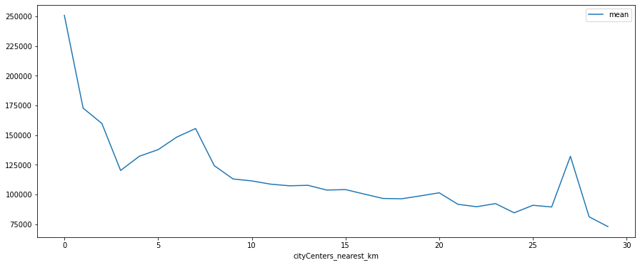

```python
x = stat_grouped_2.plot(y= 'mean', figsize=(15,6), kind = 'line')
```

Вывод: средняя цена квадратного метра снижается с удалением от центра. Однако, есть локальные пики в районе 7 км от центра и 27 км от центра. Что может быть объяснено тем, что там находится элитная недвижимость, где могут находиться дорогие коттеджные поселки. Масс-сегмент находится на расстоянии от 11 до 16 км от центра (наибольшее количество продаваемой недвижимости)

### Общий вывод

1. Основной фактор, влияющий на стоимость квартиры - это площадь.
2. Квартиры в центре СПб стоят дороже, чем при удалении от него, однако зависимость эта не очень сильная. По-видимому, это объясняется тем, что есть элитные районы, формально находящиеся далеко от центра, но имеющие очень высокую стоимость квартир. Также же это может объясняться тем, что центр СПб состоит, в основном, из старых домов, где квартиры могут требовать ремонта, либо расселяемые коммуналки. Вероятно, этот фактор тоже влияет на стоимость
3. При удалении выбросов результаты сильно не улучшались.
4. Очень большое количество незаполненных данных, характеризующих местоположение квартиры (расстояние от центра, аэропорта и парков, количество парков и водоемов). Вероятно, следует ввести единые алгоритмы, как эти данные заполнять (возможно, автоматически, в случае Санкт-Петербурга)

```python
# Посмотрим типичню квартиру всей выборке
s = ['last_price','rooms', 'ceiling_height', 'floors_total', 'living_area', 'floor', 'kitchen_area', 'balcony',
     'airports_nearest',  'parks_around3000', 'parks_nearest', 'ponds_around3000', 'ponds_nearest', 'cityCenters_nearest_km']
for column in s:
    print('Медианное значение показателя',column, ' ', df[column].median())
```

```
Медианное значение показателя last_price   4675000.0
Медианное значение показателя rooms   2.0
Медианное значение показателя ceiling_height   2.65
Медианное значение показателя floors_total   9.0
Медианное значение показателя living_area   30.0
Медианное значение показателя floor   4.0
Медианное значение показателя kitchen_area   9.0
Медианное значение показателя balcony   0.0
Медианное значение показателя airports_nearest   26732.5
Медианное значение показателя parks_around3000   0.0
Медианное значение показателя parks_nearest   451.0
Медианное значение показателя ponds_around3000   0.0
Медианное значение показателя ponds_nearest   503.0
Медианное значение показателя cityCenters_nearest_km   13.0
```

Слишком неинтересная и слишком усредненная квартира получилась. Интереснее попробовать посмотреть то же самое, но по СПб.

```python
for column in s:
    print('Медианное значение показателя',column, ' ', df.query('locality_name=="Санкт-Петербург"')[column].median().round(0))
```

```
Медианное значение показателя last_price   5500000.0
Медианное значение показателя rooms   2.0
Медианное значение показателя ceiling_height   3.0
Медианное значение показателя floors_total   9.0
Медианное значение показателя living_area   31.0
Медианное значение показателя floor   5.0
Медианное значение показателя kitchen_area   10.0
Медианное значение показателя balcony   0.0
Медианное значение показателя airports_nearest   26708.0
Медианное значение показателя parks_around3000   0.0
Медианное значение показателя parks_nearest   458.0
Медианное значение показателя ponds_around3000   1.0
Медианное значение показателя ponds_nearest   504.0
Медианное значение показателя cityCenters_nearest_km   12.0
```

Результат практически тот же самый из-за сильного преобладания квартир в Санкт-Петербурге в общей выборке. Похоже на то, что продают, в основном, небольшие двухкомнатные квартиры. Не очень информативно.

Попробуем посмотреть, на что люди смотрят при покупке квартир в центре и за его пределами.

```python
# 1. Посмотрим, сколько не заполнено
print('Процент незаполненных расстояний',(df['cityCenters_nearest_km'].isna().sum()/len(df)))
#city_center_df = df.dropna(subset=['city_center_distance_km'])
```

```
Процент незаполненных расстояний 0.2233149325045229
```

```python
# 2.  Конечно, таких значений очень много, но попробуем их удалить
city_center_df = df.dropna(subset=['cityCenters_nearest_km'])

#3. Проведем границу центра - там, где продается 25% квартир.
kv25 = city_center_df['cityCenters_nearest_km'].quantile([0.25])
print(kv25) # 9 км
#4. Посчитаем таблицу корреляций к цене в центре и за его пределами
cor_center = city_center_df.query('cityCenters_nearest_km<9').corr()\
        .sort_values('last_price', ascending=False)\
        .filter(items = ['last_price'])\
        .reset_index()
cor_not_center = city_center_df.query('cityCenters_nearest_km>9').corr()\
        .sort_values('last_price', ascending=False)\
        .filter(items = ['last_price'])\
        .reset_index()
#5. Склеим
tab = cor_center.merge(cor_not_center, on='index')
tab.columns= ['name','in_center', 'out_center']
tab
```

```
0.25    9.0
Name: cityCenters_nearest_km, dtype: float64
```

|  | name | in_center | out_center |
| --- | --- | --- | --- |
| 0 | last_price | 1.000000 | 1.000000 |
| 1 | one_meter_price | 0.799383 | 0.512863 |
| 2 | total_area | 0.628715 | 0.824083 |
| 3 | living_area | 0.541232 | 0.697455 |
| 4 | kitchen_area | 0.503217 | 0.642498 |
| 5 | rooms | 0.337315 | 0.519893 |
| 6 | ceiling_height | 0.248378 | 0.414049 |
| 7 | total_images | 0.132650 | 0.195427 |
| 8 | parks_around3000 | 0.112094 | 0.092181 |
| 9 | ponds_around3000 | 0.110742 | 0.082611 |
| 10 | floor | 0.107584 | 0.127708 |
| 11 | days_exposition | 0.062476 | 0.088967 |
| 12 | balcony | 0.061733 | 0.116142 |
| 13 | airports_nearest | 0.046067 | 0.042950 |
| 14 | is_apartment | 0.034067 | 0.013981 |
| 15 | floors_total | 0.030218 | 0.156415 |
| 16 | day_of_week_exposition | 0.017434 | -0.002212 |
| 17 | month_exposition | -0.003699 | 0.010356 |
| 18 | open_plan | -0.005063 | -0.004755 |
| 19 | studio | -0.006508 | -0.014067 |
| 20 | parks_nearest | -0.039288 | 0.067964 |
| 21 | year_exposition | -0.039962 | 0.015692 |
| 22 | ponds_nearest | -0.071323 | -0.063052 |
| 23 | cityCenters_nearest_km | -0.081849 | -0.148321 |
| 24 | cityCenters_nearest | -0.082741 | -0.148267 |

**Чек-лист готовности проекта**

Поставьте 'x' в выполненных пунктах. Далее нажмите Shift+Enter.

- [x] открыт файл
- [X] файлы изучены (выведены первые строки, метод `info()`, гистограммы и т.д.)
- [X] определены пропущенные значения
- [X] заполнены пропущенные значения там, где это возможно
- [X] есть пояснение, какие пропущенные значения обнаружены
- [X] изменены типы данных
- [X] есть пояснение, в каких столбцах изменены типы и почему
- [X] устранены неявные дубликаты в названиях населённых пунктов
- [X] устранены редкие и выбивающиеся значения (аномалии) во всех столбцах
- [X] посчитано и добавлено в таблицу: цена одного квадратного метра
- [X] посчитано и добавлено в таблицу: день публикации объявления (0 - понедельник, 1 - вторник и т.д.)
- [X] посчитано и добавлено в таблицу: месяц публикации объявления
- [X] посчитано и добавлено в таблицу: год публикации объявления
- [X] посчитано и добавлено в таблицу: тип этажа квартиры (значения — «первый», «последний», «другой»)
- [X] посчитано и добавлено в таблицу: расстояние в км до центра города
- [X] изучены и описаны следующие параметры:

  ```
    - общая площадь;
    - жилая площадь;
    - площадь кухни;
    - цена объекта;
    - количество комнат;
    - высота потолков;
    - этаж квартиры;
    - тип этажа квартиры («первый», «последний», «другой»);
    - общее количество этажей в доме;
    - расстояние до центра города в метрах;
    - расстояние до ближайшего аэропорта;
    - расстояние до ближайшего парка;
    - день и месяц публикации объявления
  ```

- [X] построены гистограммы для каждого параметра
- [X] выполнено задание: "Изучите, как быстро продавались квартиры (столбец days_exposition). Этот параметр показывает, сколько дней «висело» каждое объявление.
  - Постройте гистограмму.
  - Посчитайте среднее и медиану.
  - В ячейке типа markdown опишите, сколько обычно занимает продажа. Какие продажи можно считать быстрыми, а какие — необычно долгими?"
- [X] выполнено задание: "Какие факторы больше всего влияют на общую (полную) стоимость объекта? Постройте графики, которые покажут зависимость цены от указанных ниже параметров. Для подготовки данных перед визуализацией вы можете использовать сводные таблицы."

  ```
    - общей площади;
    - жилой площади;
    - площади кухни;
    - количество комнат;
    - типа этажа, на котором расположена квартира (первый, последний, другой);
    - даты размещения (день недели, месяц, год);
  ```

- [X] выполнено задание: "Посчитайте среднюю цену одного квадратного метра в 10 населённых пунктах с наибольшим числом объявлений. Выделите населённые пункты с самой высокой и низкой стоимостью квадратного метра. Эти данные можно найти по имени в столбце `locality_name`."
- [X] выполнено задание: "Ранее вы посчитали расстояние до центра в километрах. Теперь выделите квартиры в Санкт-Петербурге с помощью столбца `locality_name` и вычислите среднюю цену каждого километра. Опишите, как стоимость объектов зависит от расстояния до центра города."
- [X] в каждом этапе есть промежуточные выводы
- [X] есть общий вывод